# Seminar

Group D

7/1/2020

```r
library(data.table)
library(dplyr)
```

```r
library(ggplot2)
```

```r
setwd("C:/Users/buith/Downloads/Seminar/Patnet_data")
EPO_Inv_reg <- fread("REGPAT_201803/201803_EPO_Inv_reg.txt", encoding = "UTF-8")
EPO_IPC <- fread("REGPAT_201803/201803_EPO_IPC.txt", encoding = "UTF-8")
REGPAT_Regions_NUTS3_TL3 <- fread("REGPAT_201803/REGPAT_Regions_NUTS3_TL3.txt", encoding = "UTF-8")
QUALITY_EPO <- fread('Indicators_201803/201803_OECD_PATENT_QUALITY_EPO.txt', encoding = "UTF-8")
```

###Modify data

```r
thu_up_reg<- unique(REGPAT_Regions_NUTS3_TL3[grep("THÜRINGEN", REGPAT_Regions_NUTS3_TL3$Up_reg_label),])
thu_inv<- EPO_Inv_reg[EPO_Inv_reg$Reg_code %in% thu_up_reg$Reg_Code,]
EPO_IPC$ipc3 <- substr(EPO_IPC$IPC, 1,3)
thu_data_de <- inner_join(thu_inv, thu_up_reg, by = c("Reg_code" = "Reg_Code"))
thu_data_de <- thu_data_de %>%mutate(Thuringia = case_when(thu_data_de$Up_reg_label =="OSTTHÜRINGEN"~"EAST", thu_data_de$Up_reg_label=="MITTELTHÜRINGEN"~"CENTRAL", thu_data_de$Up_reg_label=="SÜDTHÜRINGEN"~"SOUTH", TRUE~"NORTH"))
thu_ipc <- EPO_IPC[EPO_IPC$Appln_id %in% thu_inv$Appln_id,]
thu_ipc_7716 <- copy(thu_ipc)
thu_ipc<-thu_ipc%>%mutate(Prio_Year = case_when(thu_ipc$Prio_Year %in%1991:1995~1, thu_ipc$Prio_Year %in%1996:2000~2, thu_ipc$Prio_Year %in%2001:2005~3, thu_ipc$Prio_Year %in%2006:2010~4))
thu_ipc3<- inner_join(thu_ipc, unique(thu_data_de[ , c("Appln_id", "Reg_code", "Thuringia")]), by = c("Appln_id" = "Appln_id"))
thu_data<- inner_join(thu_data_de, unique(thu_ipc[, c("Appln_id", "Prio_Year", "App_year")]),by = c("Appln_id" = "Appln_id"))
thu_open <- thu_data[thu_data$Inv_share < 1,]
thu_open <- unique(thu_open[, c("Appln_id", "Person_id", "Reg_share", "Inv_share")])
open_close <- aggregate(thu_open[,c("Inv_share")], by = list(thu_open$Appln_id), sum)
names(open_close) <- c("Appln_id", "Total_invshare")
open_close$open_or_close <- ifelse(open_close$Total_invshare < 1, 1, 0) # 1 for having external knowledge sources
thu_data <- merge(thu_data, open_close, by="Appln_id", all.x = TRUE)
thu_data[thu_data$Inv_share == 1, c("Total_invshare")] <- 1
thu_data[thu_data$Inv_share == 1, c("open_or_close")] <- 0
thu_central <- filter(thu_data, Thuringia %in% "CENTRAL" & Prio_Year %in% 1:4)
thu_east <- filter(thu_data, Thuringia %in% "EAST" & Prio_Year %in% 1:4)
thu_south <- filter(thu_data, Thuringia %in% "SOUTH" & Prio_Year %in% 1:4)
thu_north <- filter(thu_data, Thuringia %in% "NORTH" & Prio_Year %in% 1:4)
```

I.General view of Thuringia patents activities

1. Number of patents by sub-regions 1990-2010

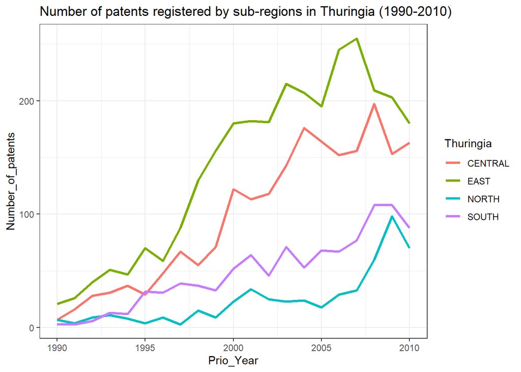

```r
thu_data_7716 <- left_join(thu_data_de,
                      unique(thu_ipc_7716[ , c("Appln_id", "Prio_Year", "App_year")]),
                      by = c("Appln_id" = "Appln_id"))
thu_data_9020=subset(thu_data_7716,Prio_Year%in%1990:2010)
thu_data_9020 <- unique(thu_data_9020[,c("Appln_id", "Thuringia", "Prio_Year")])
thu_data_9020 <- aggregate(thu_data_9020[,c("Appln_id")], by= list(thu_data_9020$Prio_Year, thu_data_9020$Thuringia), length)
names(thu_data_9020) <- c("Prio_Year", "Thuringia", "Number_of_patents")
ggplot(thu_data_9020, aes(x= Prio_Year, y= Number_of_patents)) +
  geom_line(aes(color = Thuringia), size = 1.2) +
  theme_bw()+
  ggtitle("Number of patents registered by sub-regions in Thuringia (1990-2010)")
```

2. IPC3 class of patents by sub-regions

```r
thu_ipc3_unique=unique(thu_ipc3[,c("Appln_id","ipc3","Prio_Year","Thuringia")])
total_reg_ipc <- aggregate(thu_ipc3$ipc3, list(thu_ipc3$Thuringia,thu_ipc3$ipc3), length)
names(total_reg_ipc)<-c("Thuringia","ipc3","total")
ipc3_north=subset(total_reg_ipc,Thuringia=="NORTH")
ipc3_south=subset(total_reg_ipc,Thuringia=="SOUTH")
ipc3_east=subset(total_reg_ipc,Thuringia=="EAST")
ipc3_central=subset(total_reg_ipc,Thuringia=="CENTRAL")
central_ipc3=head(ipc3_central[order(ipc3_central$total, decreasing = T),],5)
north_ipc3=head(ipc3_north[order(ipc3_north$`total`,decreasing=T),],5)
east_ipc3=head(ipc3_east[order(ipc3_east$`total`,decreasing=T),],5)
south_ipc3=head(ipc3_south[order(ipc3_south$total,decreasing=T),],5)
top_5<- cbind(central_ipc3, east_ipc3, south_ipc3, north_ipc3)
```

II.Technological Capability

```r
#define a funtion to measure the technological capability of a region over time
#input: patent data of this region, quality of patent dataframe
descriptive_stats <- function(thu_central, QUALITY_EPO) {
  central <- QUALITY_EPO[QUALITY_EPO$appln_id %in% thu_central$Appln_id, c("appln_id","patent_scope","fwd_cits7")]
  names(central) <- c("Appln_id", "Patent_Scope", "Forward_Citations")
  central <- merge(thu_central, central, by = "Appln_id", all = TRUE )
  central <- unique(central[,c("Appln_id","Prio_Year", "Patent_Scope", "Forward_Citations", "open_or_close")])
  central$Count <- 1

  central_pat <- aggregate(central[,c("Patent_Scope", "Forward_Citations", "Count", "open_or_close")], by=list(central$Prio_Year), sum)
  central_pat$AVG_Scope <- round(central_pat$Patent_Scope/central_pat$Count,4)
  central_pat$AVG_FWDCITS <- round(central_pat$Forward_Citations/central_pat$Count, 4)
  names(central_pat)[1] <- c("Period")
  central_pat$Period<- c("1991-1995","1996-2000","2001-2005","2006-2010")
  central_pat$percent_open <- round(central_pat$open_or_close*100/central_pat$Count, 4)
  return(central_pat)
}
central_pat <- descriptive_stats(thu_central, QUALITY_EPO)
east_pat <- descriptive_stats(thu_east, QUALITY_EPO)
north_pat <- descriptive_stats(thu_north, QUALITY_EPO)
south_pat <- descriptive_stats(thu_south, QUALITY_EPO)
```

1. Number of Patents by sub-regions

```r
no_pat <- data.frame(matrix(ncol = 0, nrow = 4))
no_pat$Period <- central_pat$Period
no_pat$Central <- central_pat$Count
no_pat$East <- east_pat$Count
no_pat$South <- south_pat$Count
no_pat$North <- north_pat$Count
no_pat_melt <- melt(as.data.table(no_pat), variable.name ="Region", value.name = "Number_of_patents")
```

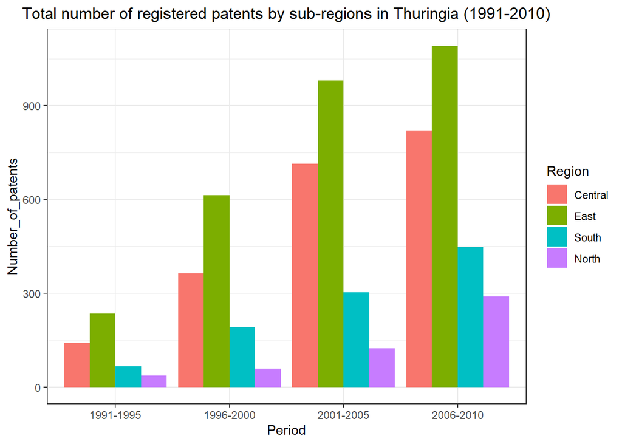

```r
ggplot(no_pat_melt, aes(Period, Number_of_patents, fill = Region)) +
  geom_bar(stat="identity", position = position_dodge()) +
  theme_bw()+
  ggtitle("Total number of registered patents by sub-regions in Thuringia (1991-2010)")+
  theme(plot.title = element_text(hjust = 0.5))
```

2. Average Scope of paten by sub-regions

```r
avg_scope <- data.frame(matrix(ncol=0, nrow = 4))
avg_scope$Period <- central_pat$Period
avg_scope$Central <- central_pat$AVG_Scope
avg_scope$East <- east_pat$AVG_Scope
avg_scope$South <- south_pat$AVG_Scope
avg_scope$North <- north_pat$AVG_Scope
avg_scope_melt <- melt(as.data.table(avg_scope), variable.name ="Region", value.name = "Average_Scope")
```

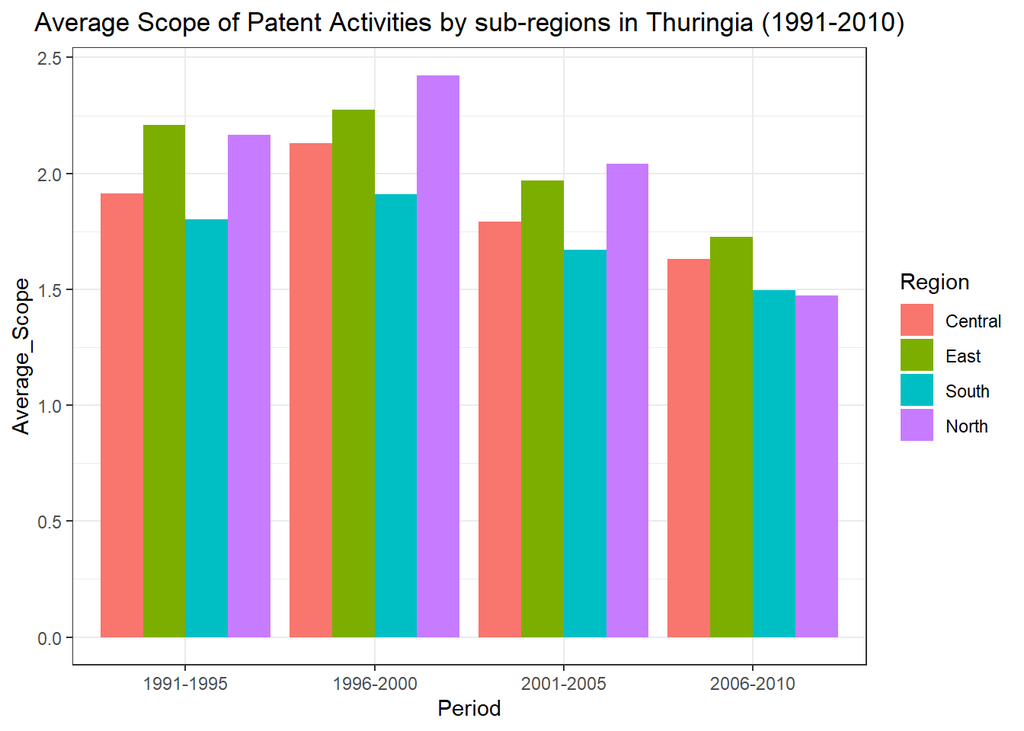

```r
ggplot(avg_scope_melt, aes(Period, Average_Scope, fill = Region)) +
  geom_bar(stat="identity", position = position_dodge()) +
  theme_bw() +
  ggtitle("Average Scope of Patent Activities by sub-regions in Thuringia (1991-2010)")+
  theme(plot.title = element_text(hjust = 0.5))
```

3. Average Forward Citation of patents by sub-regions

```r
avg_fwdcits <- data.frame(matrix(ncol=0, nrow = 4))
avg_fwdcits$Period <- central_pat$Period
avg_fwdcits$Central <- central_pat$AVG_FWDCITS
avg_fwdcits$East <- east_pat$AVG_FWDCITS
avg_fwdcits$South <- south_pat$AVG_FWDCITS
avg_fwdcits$North <- north_pat$AVG_FWDCITS
avg_fwdcits_melt <- melt(as.data.table(avg_fwdcits), variable.name ="Region", value.name = "Average_Forward_Citations")
```

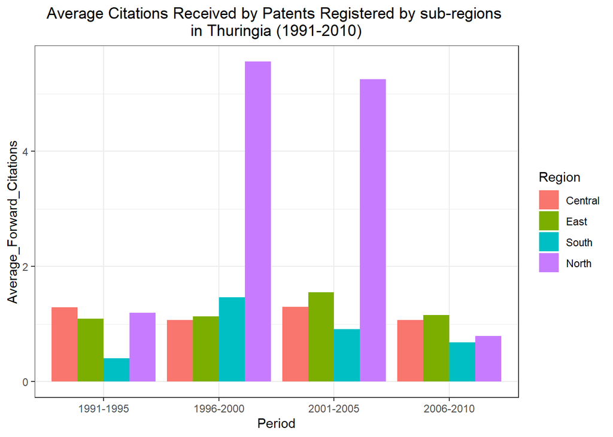

```r
ggplot(avg_fwdcits_melt, aes(Period, Average_Forward_Citations, fill = Region)) +
  geom_bar(stat="identity", position = position_dodge()) +
  theme_bw() +
  ggtitle("Average Citations Received by Patents Registered by sub-regions \nin Thuringia (1991-2010)")+
  theme(plot.title = element_text(hjust = 0.5))
```

Forward citations is the citations received by a patent – can be used to assess the technological impact of inventions their cross-technology, geographical impact. The technological impact of inventions can indicate the economic importance of patents. The value of a patent and the number and quality of its forward citations have repeatedly been found to becorrelated. Therefore forward citation is a good indicator to study about technology capabilies.

In our analyse result,the average citations received by patents registered by North in the second and third periods were significantly higher than patents of other sub-regions. It could be explained by the fact that the number of patents in the North was too low so that individual patents had a large impact on the overall view. There were two patents in the north by the Max-Planck-Society on RNA which are highly cited, which could be considered as outliers. Generally, the average citations of patents registered by four sub-regions are smaller than 2, except for North Thuringia in 1996-2000 and 2001-2005. It seems to be difficult to state which sub-region has the most valuable patent during the whole period based on the average measure.

4 Openness to External Knowledge

```r
percentage_open <- data.frame(matrix(ncol = 0, nrow = 4))
percentage_open$Period <- central_pat$Period
percentage_open$Central <- central_pat$percent_open
percentage_open$East <- east_pat$percent_open
percentage_open$North <- north_pat$percent_open
percentage_open$South <- south_pat$percent_open
percentage_open_melt <- melt(as.data.table(percentage_open), variable.name = "Region", value.name = "Openness_to_External_Knowldge")
```

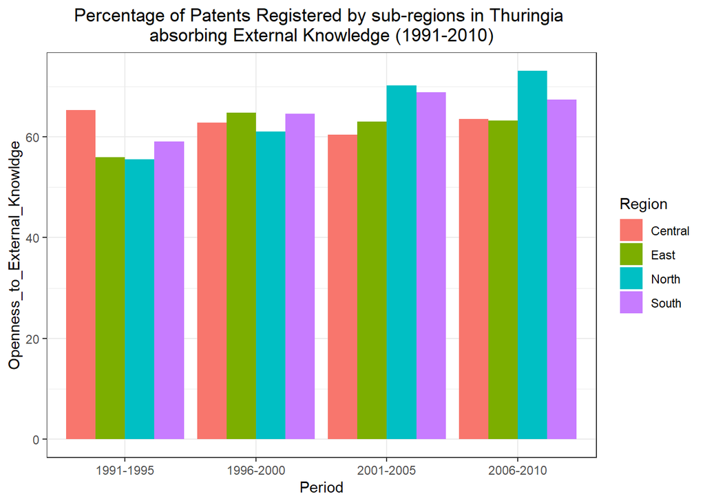

```r
ggplot(percentage_open_melt, aes(Period, Openness_to_External_Knowldge, fill= Region)) +
  geom_bar(stat="identity", position = position_dodge()) +
  theme_bw() +
  ggtitle("Percentage of Patents Registered by sub-regions in Thuringia \nabsorbing External Knowledge (1991-2010)")+
  theme(plot.title = element_text(hjust = 0.5))
```

2. Technological Proximity

```r
sub_region <- c("CENTRAL", "EAST", "SOUTH", "NORTH")
for (region in sub_region){
  assign(paste(region, "_ipc", sep =""), unique(filter(thu_ipc3, Thuringia %in% region & Prio_Year %in% 1:4)[,c("Appln_id", "Prio_Year", "ipc3")]))
}
IPC_share_def <- function(CENTRAL_ipc, names_list = c("IPC3", "c1","c2","c3", "c4")){
  ###IPC3_share in every period
      IPC3_share_central <- aggregate(CENTRAL_ipc$Appln_id, by=list(CENTRAL_ipc$Prio_Year, CENTRAL_ipc$ipc3), length)
      total_ipc <- aggregate(IPC3_share_central$x, by=list(IPC3_share_central$Group.1), sum)
      IPC3_share_central <- merge(IPC3_share_central,total_ipc, all=T, by="Group.1")
      IPC3_share_central$share <- IPC3_share_central$x.x/IPC3_share_central$x.y
      names(IPC3_share_central) <- names_list
  return(IPC3_share_central)
}
IPC3_share_central <- IPC_share_def(CENTRAL_ipc, c("Period", "IPC3", "n_cipc3", "total_cipc3", "cipc3_share"))
IPC3_share_east <- IPC_share_def(EAST_ipc, c("Period", "IPC3", "n_eipc3", "total_eipc3", "eipc3_share"))
IPC3_share_south <- IPC_share_def(SOUTH_ipc, c("Period", "IPC3", "n_sipc3", "total_sipc3", "sipc3_share"))
IPC3_share_north <- IPC_share_def(NORTH_ipc, c("Period", "IPC3", "n_nipc3", "total_nipc3", "nipc3_share"))
#IPC3 share for each time period
for (i in 1:4){
  assign(paste("IPC3_", i, sep=""), Reduce(function(x, y) merge(x, y, all=TRUE), list(IPC3_share_central[IPC3_share_central$Period==i , c(2,5)], IPC3_share_east[IPC3_share_east$Period==i,c(2,5)], IPC3_share_south[IPC3_share_south$Period==i,c(2,5)], IPC3_share_north[IPC3_share_north$Period==i,c(2,5)])))
}
```

```r
tech_distance_def <- function(IPC3_1){
    IPC3_1[is.na(IPC3_1)] <- 0
    names(IPC3_1) <- c("IPC3", "Central", "East", "South", "North")
    IPC3_1$Diff_CE <- (IPC3_1$Central -IPC3_1$East)**2
    IPC3_1$Diff_CS <- (IPC3_1$Central -IPC3_1$South)**2
    IPC3_1$Diff_CN <- (IPC3_1$Central -IPC3_1$North)**2
    IPC3_1$Diff_ES <- (IPC3_1$East -IPC3_1$South)**2
    IPC3_1$Diff_EN <- (IPC3_1$East -IPC3_1$North)**2
    IPC3_1$Diff_SN <- (IPC3_1$South -IPC3_1$North)**2
    CE <- round(sqrt(sum(IPC3_1$Diff_CE)),3)
    CS <- round(sqrt(sum(IPC3_1$Diff_CS)),3)
    CN <- round(sqrt(sum(IPC3_1$Diff_CN)),3)
    ES <- round(sqrt(sum(IPC3_1$Diff_ES)),3)
    EN <- round(sqrt(sum(IPC3_1$Diff_EN)),3)
    SN <- round(sqrt(sum(IPC3_1$Diff_SN)),3)
    return(c(CE, CS, CN, ES, EN, SN))
}
dis1 <- tech_distance_def(IPC3_1)
dis2 <- tech_distance_def(IPC3_2)
dis3 <- tech_distance_def(IPC3_3)
dis4 <- tech_distance_def(IPC3_4)
tech_proxi <- as.data.frame(rbind(dis1, dis2, dis3, dis4))
names(tech_proxi) <- c("Central_East","Central_South", "Central_North", "East_South", "East_North", "South_North")
tech_proxi$Period <- c(1,2,3,4)
#rownames(tech_proxi) <- 1:4
#distance bwt Central with others
central <- tech_proxi[,c("Period", "Central_East","Central_South", "Central_North")]
central <- melt(as.data.table(central), id.vars = 1, variable.name = "Regions", value.name = "Technological_Distance")
east <- tech_proxi[,c("Period", "Central_East", "East_South", "East_North")]
east <- melt(as.data.table(east), id.vars = 1, variable.name = "Regions", value.name ="Technological_Distance")
south <- tech_proxi[,c("Period", "Central_South", "East_South", "South_North")]
south <- melt(as.data.table(south), id.vars = 1, variable.name = "Regions", value.name ="Technological_Distance")
north <- tech_proxi[,c("Period", "Central_North", "East_North", "South_North")]
north <- melt(as.data.table(north), id.vars = 1, variable.name = "Regions", value.name ="Technological_Distance")
tech_pro <- melt(as.data.table(tech_proxi), id.vars = 7, variable.name = "Regions", value.name ="Technological_Distance")
tech_proxi
```

|  | Central_East | Central_South | Central_North | East_South | East_North | South_North | Period |
| --- | --- | --- | --- | --- | --- | --- | --- |
| dis1 | 0.165 | 0.209 | 0.164 | 0.238 | 0.184 | 0.179 | 1 |
| dis2 | 0.093 | 0.177 | 0.129 | 0.221 | 0.176 | 0.183 | 2 |
| dis3 | 0.105 | 0.178 | 0.182 | 0.253 | 0.208 | 0.214 | 3 |
| dis4 | 0.116 | 0.153 | 0.251 | 0.215 | 0.284 | 0.245 | 4 |

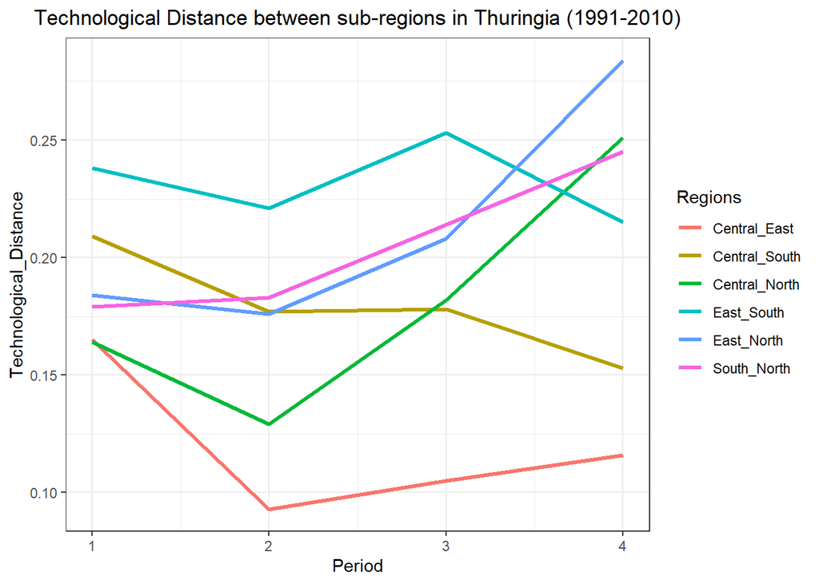

```r
ggplot(tech_pro, aes(x= Period, y= Technological_Distance)) +
  geom_line(aes(color = Regions), size = 1.2) +
  theme_bw()+
  ggtitle("Technological Distance between sub-regions in Thuringia (1991-2010)")+
  theme(plot.title = element_text(hjust = 0.5))
```